# shooting_project

C. Tooley

2024-09-04

## NYC shooting project

Load in the libraries used for this analysis. Specific libraries not used in class are ‘ggstatsplot’ which I use for my favorite ggplot theme and ‘forecast’ which is a library that allows you to conduct analysis on time series data.

Then read in the NYC shooting data. View the nyc_shooting dataframe, and provide a summary of all variables.

```r
library(tidyverse)
```

```r
library(ggstatsplot)
library(forecast)
nyc_shooting <- read_csv('https://data.cityofnewyork.us/api/views/833y-fsy8/rows.csv?accessType=DOWNLOAD')
nyc_shooting
```

```
## # A tibble: 28,562 × 21
##    INCIDENT_KEY OCCUR_DATE OCCUR_TIME BORO      LOC_OF_OCCUR_DESC PRECINCT
##           <dbl> <chr>      <time>     <chr>     <chr>                <dbl>
##  1    244608249 05/05/2022 00:10      MANHATTAN INSIDE                  14
##  2    247542571 07/04/2022 22:20      BRONX     OUTSIDE                 48
##  3     84967535 05/27/2012 19:35      QUEENS    <NA>                   103
##  4    202853370 09/24/2019 21:00      BRONX     <NA>                    42
##  5     27078636 02/25/2007 21:00      BROOKLYN  <NA>                    83
##  6    230311078 07/01/2021 23:07      MANHATTAN <NA>                    23
##  7    229224142 06/07/2021 19:55      QUEENS    <NA>                   113
##  8    231246224 07/22/2021 01:47      BROOKLYN  <NA>                    77
##  9    228559720 05/22/2021 18:39      BRONX     <NA>                    48
## 10    238210279 12/22/2021 23:17      BRONX     <NA>                    49
## # ℹ 28,552 more rows
## # ℹ 15 more variables: JURISDICTION_CODE <dbl>, LOC_CLASSFCTN_DESC <chr>,
## #   LOCATION_DESC <chr>, STATISTICAL_MURDER_FLAG <lgl>, PERP_AGE_GROUP <chr>,
## #   PERP_SEX <chr>, PERP_RACE <chr>, VIC_AGE_GROUP <chr>, VIC_SEX <chr>,
## #   VIC_RACE <chr>, X_COORD_CD <dbl>, Y_COORD_CD <dbl>, Latitude <dbl>,
## #   Longitude <dbl>, Lon_Lat <chr>
```

## Cleaning

I started with the imported nyc_shooting and use the function mutate to change all categorical variables of location types, age groups, sex, and race into factors. After converting the desired variables into factors by using the mutate function, I converedt occur_date into the month/day/year using the lubridate mdy() function. Finally, I selected all data except for x_coord, y_coord, and Lon_Lat because I don’t know what the x and y coordinates refer to, and Lon_Lat because I would split it into two latitude and longitude columns if I wanted to map the data and those columns already exist. I haven’t removed any more than that because I don’t yet know the variables I will be interested in analyzing and modeling.

There are a number of NA data in location_desc, loc_of_occur_desc, and loc_classfctn_desc but I am not going to filter the NA location variables because I will be getting rid of a significant amount of data but don’t intend to do any any analysis on whether or not a shooting happened inside for example.

```r
nyc_shooting_clean <- nyc_shooting %>%
  mutate(BORO = as_factor(BORO),
        LOC_OF_OCCUR_DESC = as_factor(LOC_OF_OCCUR_DESC),
        LOC_CLASSFCTN_DESC = as_factor(LOC_CLASSFCTN_DESC),
        LOCATION_DESC = as_factor(LOCATION_DESC),
        PERP_AGE_GROUP = as_factor(PERP_AGE_GROUP),
        PERP_SEX = as_factor(PERP_SEX),
        PERP_RACE = as_factor(PERP_RACE),
        VIC_AGE_GROUP = as_factor(VIC_AGE_GROUP),
        VIC_SEX = as_factor(VIC_SEX),
        VIC_RACE = as_factor(VIC_RACE),
        OCCUR_DATE = mdy(OCCUR_DATE),
        PERP_AGE_GROUP = fct_recode(PERP_AGE_GROUP, 'UNKNOWN' = '(null)'),
        PERP_AGE_GROUP = fct_relevel(PERP_AGE_GROUP, "<18", "18-24", "25-44",
                                     "45-64", "65+", "UNKNOWN"),
        VIC_AGE_GROUP = fct_relevel(VIC_AGE_GROUP, "<18", "18-24", "25-44",
                                     "45-64", "65+", "UNKNOWN")) %>%
  select(-c(X_COORD_CD,Y_COORD_CD,Lon_Lat)) %>%
  filter(PERP_AGE_GROUP != '1020',
         PERP_AGE_GROUP != '224',
         PERP_AGE_GROUP != '940',
         PERP_AGE_GROUP != '1028',
         PERP_AGE_GROUP != '(null)',
         VIC_AGE_GROUP != '1022') %>%
  droplevels()


nyc_shooting_clean
```

```
## # A tibble: 19,213 × 18
##    INCIDENT_KEY OCCUR_DATE OCCUR_TIME BORO      LOC_OF_OCCUR_DESC PRECINCT
##           <dbl> <date>     <time>     <fct>     <fct>                <dbl>
##  1    244608249 2022-05-05 00:10      MANHATTAN INSIDE                  14
##  2    247542571 2022-07-04 22:20      BRONX     OUTSIDE                 48
##  3    202853370 2019-09-24 21:00      BRONX     <NA>                    42
##  4     27078636 2007-02-25 21:00      BROOKLYN  <NA>                    83
##  5    238210279 2021-12-22 23:17      BRONX     <NA>                    49
##  6    236818010 2021-11-22 21:40      MANHATTAN <NA>                    28
##  7    224465138 2021-02-16 11:55      MANHATTAN <NA>                     7
##  8    233429422 2021-09-11 15:13      BROOKLYN  <NA>                    73
##  9    224079498 2021-02-06 21:14      BRONX     <NA>                    42
## 10    224354730 2021-02-12 05:15      BRONX     <NA>                    43
## # ℹ 19,203 more rows
## # ℹ 12 more variables: JURISDICTION_CODE <dbl>, LOC_CLASSFCTN_DESC <fct>,
## #   LOCATION_DESC <fct>, STATISTICAL_MURDER_FLAG <lgl>, PERP_AGE_GROUP <fct>,
## #   PERP_SEX <fct>, PERP_RACE <fct>, VIC_AGE_GROUP <fct>, VIC_SEX <fct>,
## #   VIC_RACE <fct>, Latitude <dbl>, Longitude <dbl>
```

```r
summary(nyc_shooting_clean)
```

```
##   INCIDENT_KEY         OCCUR_DATE          OCCUR_TIME
##  Min.   :  9953245   Min.   :2006-01-01   Length:19213
##  1st Qu.: 51745756   1st Qu.:2008-09-28   Class1:hms
##  Median : 86146319   Median :2012-08-07   Class2:difftime
##  Mean   :122903234   Mean   :2014-01-07   Mode  :numeric
##  3rd Qu.:206898907   3rd Qu.:2020-01-01
##  Max.   :279758069   Max.   :2023-12-29
##
##             BORO      LOC_OF_OCCUR_DESC    PRECINCT      JURISDICTION_CODE
##  MANHATTAN    :2731   INSIDE :  460     Min.   :  1.00   Min.   :0.000
##  BRONX        :5862   OUTSIDE: 2504     1st Qu.: 43.00   1st Qu.:0.000
##  QUEENS       :2905   NA's   :16249     Median : 67.00   Median :0.000
##  BROOKLYN     :7054                     Mean   : 64.99   Mean   :0.304
##  STATEN ISLAND: 661                     3rd Qu.: 81.00   3rd Qu.:0.000
##                                         Max.   :123.00   Max.   :2.000
##                                                          NA's   :2
##   LOC_CLASSFCTN_DESC                   LOCATION_DESC  STATISTICAL_MURDER_FLAG
##  STREET    : 1884    MULTI DWELL - PUBLIC HOUS:3255   Mode :logical
##  HOUSING   :  460    MULTI DWELL - APT BUILD  :2319   FALSE:15393
##  DWELLING  :  243    (null)                   :1709   TRUE :3820
##  COMMERCIAL:  208    PVT HOUSE                : 691
##  OTHER     :   59    GROCERY/BODEGA           : 576
##  (Other)   :  110    (Other)                  :1655
##  NA's      :16249    NA's                     :9008
##  PERP_AGE_GROUP   PERP_SEX              PERP_RACE     VIC_AGE_GROUP  VIC_SEX
##  <18    :1682   M     :16163   BLACK         :11900   <18    :2142   M:17137
##  18-24  :6437   (null): 1141   WHITE HISPANIC: 2508   18-24  :6815   F: 2067
##  25-44  :6041   F     :  444   UNKNOWN       : 1803   25-44  :8628   U:    9
##  45-64  : 699   U     : 1465   BLACK HISPANIC: 1392   45-64  :1408
##  65+    :  65                  (null)        : 1141   65+    : 161
##  UNKNOWN:4289                  WHITE         :  298   UNKNOWN:  59
##                                (Other)       :  171
##                            VIC_RACE        Latitude       Longitude
##  BLACK                         :13045   Min.   :40.52   Min.   :-74.23
##  WHITE                         :  582   1st Qu.:40.67   1st Qu.:-73.94
##  WHITE HISPANIC                : 3233   Median :40.71   Median :-73.91
##  BLACK HISPANIC                : 1949   Mean   :40.74   Mean   :-73.91
##  ASIAN / PACIFIC ISLANDER      :  343   3rd Qu.:40.83   3rd Qu.:-73.88
##  UNKNOWN                       :   52   Max.   :40.91   Max.   :-73.71
##  AMERICAN INDIAN/ALASKAN NATIVE:    9   NA's   :58      NA's   :58
```

##Visualization and analysis

After taking a look at some of the cleaned data, I’ve decided to take a look at overall shooting trends by Borough. Ive started by using the group_by() function to group by year and Borough to get the data required to make a line graph and a box and whisker plot of the data.

The intent of the line plots are to determine if there are any obvious or interesting trends in the number of shootings over time. There appears to be significant decrease in shootings until 2018/2019 where they reverse course and increase again until 2022 when they all begin to decline again.

The intent of the box and whisker plot is to get a visual of some rough summary statistics. From the box and whisper I see a few major takeaways. Booklyn and the Bronx have the highest mean shooting and variance. Staten island appears to have a significantly lower mean and variance in total shootings.

```r
#get yearly shooting counts
shooting_by_year <- nyc_shooting_clean %>%
  mutate(year = year(OCCUR_DATE)) %>%
  group_by(year, BORO) %>%
  summarize(count = n())
#get mean, sd, from the counts for box and whisker
summary_stats <- shooting_by_year %>%
  group_by(BORO) %>%
  summarize(
    mean = mean(count),
    sd = sd(count),
    .groups = 'drop'
  )

shooting_by_year
```

```
## # A tibble: 90 × 3
## # Groups:   year [18]
##     year BORO          count
##    <dbl> <fct>         <int>
##  1  2006 MANHATTAN       251
##  2  2006 BRONX           530
##  3  2006 QUEENS          273
##  4  2006 BROOKLYN        786
##  5  2006 STATEN ISLAND    50
##  6  2007 MANHATTAN       207
##  7  2007 BRONX           473
##  8  2007 QUEENS          193
##  9  2007 BROOKLYN        685
## 10  2007 STATEN ISLAND    48
## # ℹ 80 more rows
```

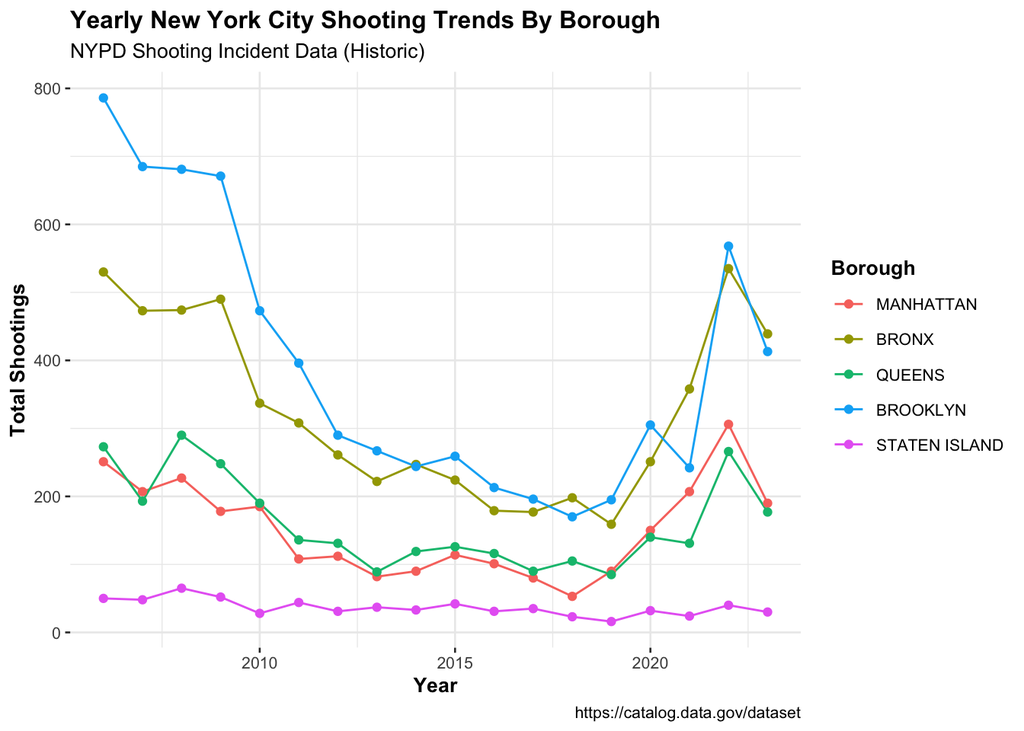

```r
#plot line graph of yearly shooting counts by borough
ggplot(shooting_by_year) +
  aes(x = year, y = count, colour = BORO) +
  geom_line() +
  geom_point()+
  labs(
    x = "Year",
    y = "Total Shootings",
    title = "Yearly New York City Shooting Trends By Borough",
    subtitle = "NYPD Shooting Incident Data (Historic)",
    caption = " https://catalog.data.gov/dataset",
    color = "Borough"
  ) +
  theme_ggstatsplot() +
  theme(legend.position = 'right')
```

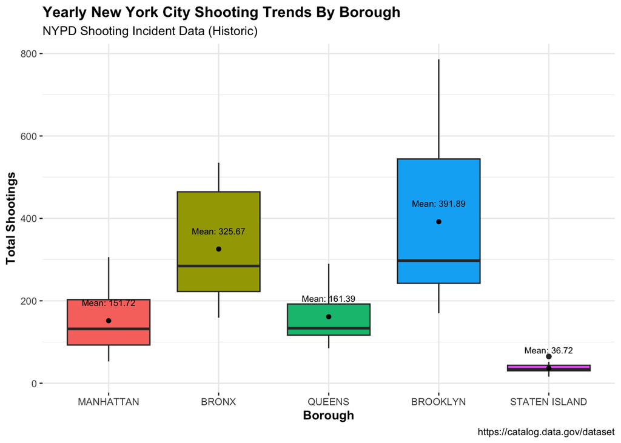

```r
#box and whisker by borough
ggplot(shooting_by_year) +
  aes(x = BORO, y = count, fill = BORO) +
  geom_boxplot() +
  geom_point(data = summary_stats, aes(y = mean), color = "black", size = 1.3) +
  #stat_summary(fun = mean, geom = "point", color = "black", size = 1.3) +
  geom_text(data = summary_stats,
            aes(y = mean, label = paste0("Mean: ",round(mean,2))), vjust = -2.4, color = "black", size = 2.5) +
  theme_ggstatsplot()+
  labs(
    x = "Borough",
    y = "Total Shootings",
    title = "Yearly New York City Shooting Trends By Borough",
    subtitle = "NYPD Shooting Incident Data (Historic)",
    caption = " https://catalog.data.gov/dataset"
  )+
  theme(legend.position = 'none')
```

After looking at yearly statistics I wondered what they would look like from a monthly perspective. I grouped by month, year, and borough to get a higher resolution look at shootings over time.

The line graph below shows oscillations over time that look like they might show a seasonal trend.

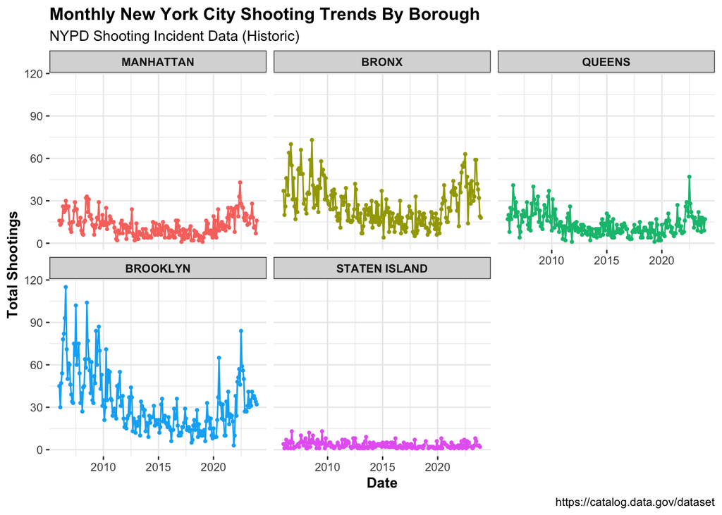

```r
shooting_by_month <- nyc_shooting_clean %>%
    mutate(month = month(OCCUR_DATE),
           year = year(OCCUR_DATE)) %>%
    group_by(month, year, BORO) %>%
    summarize(count = n(), .groups = 'drop')

shooting_by_month <- shooting_by_month %>%
    mutate(date = as.Date(paste(year, month, "01", sep = "-"), format = "%Y-%m-%d"))

ggplot(shooting_by_month, aes(x = date, y = count, color = BORO))+
  geom_line(size = .5) +
  geom_point(size = .7) +
  facet_wrap(~BORO)+
  theme_ggstatsplot()+
  labs(
    x = "Date",
    y = "Total Shootings",
    title = "Monthly New York City Shooting Trends By Borough",
    subtitle = "NYPD Shooting Incident Data (Historic)",
    caption = " https://catalog.data.gov/dataset"
  )+
  theme(legend.position = 'none')
```

## Bias

After discovering that there may be a seasonal bias to the data I began to wonder how I could confirm that hunch so, in order to look at the monthly trends below I’ve grouped by borough and month only and plotted the number of shootings per month which has confirmed my assumptions that there is indeed seasonality in the shooting data with a much higher number of shooting occurring in the summer months and fewer shootings in the winter. A trend that persists across boroughs with the exception of Staten Island.

```r
seasons <- nyc_shooting_clean %>%
     mutate(month = month(OCCUR_DATE)) %>%
     group_by(month, BORO) %>%
     summarize(count = n())
```

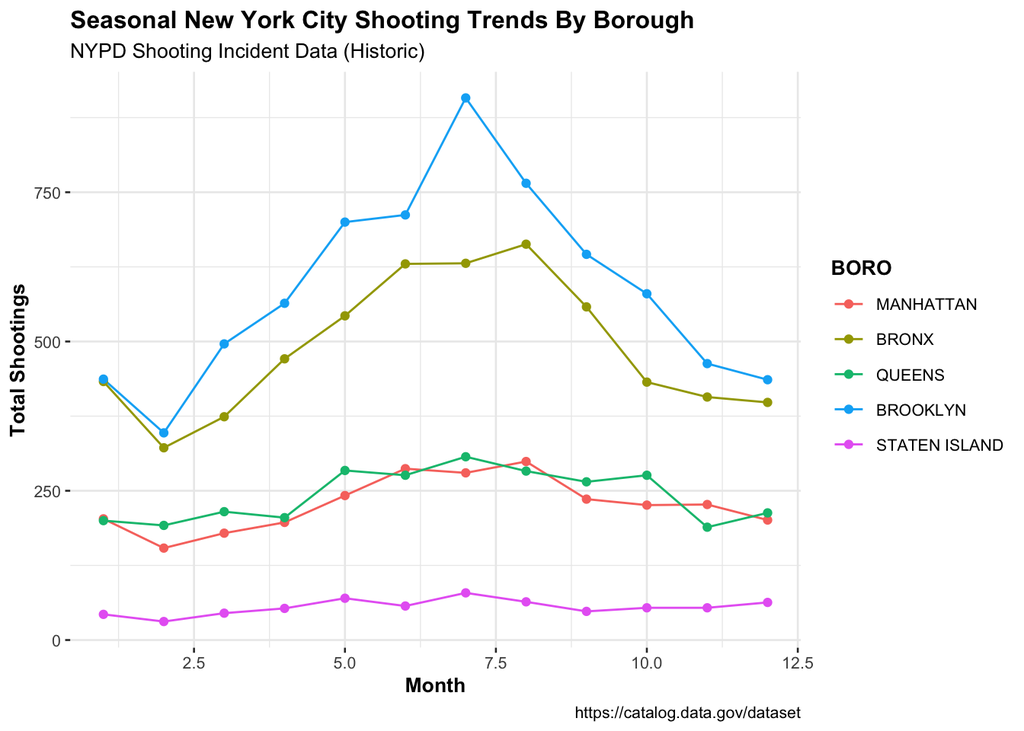

```r
ggplot(seasons) +
     aes(x = month, y = count, colour = BORO) +
     geom_line() +
     geom_point()+
  theme_ggstatsplot()+
  labs(
    x = "Month",
    y = "Total Shootings",
    title = "Seasonal New York City Shooting Trends By Borough",
    subtitle = "NYPD Shooting Incident Data (Historic)",
    caption = " https://catalog.data.gov/dataset"
  )+
  theme(legend.position = 'right')
```

After confirming my suspicion that shootings were seasonal, I wondered if I could model the data in a way that minimized the noise from seasonality. This question led me to a library called forecast which allows you to to correct time series data for what is called called seasonality.

I’ve made a list of boroughs and iterated through them. Each iteration takes the shooting_by_month dataset above filters all boro data not being analyzed per loop and then arranges it by year then month. Ive then made a time series object that starts at the earliest date and establishes 12 months in the object.

With this new time series object, I then used stl() to remove the ‘seasonality’ from the data and finally plotted the decomposed time series data which yielded a plot for each borough that models and takes the raw data, determines a seasonal contribution, shows the trend with seasonal bias removed, and finally stl() displays the remainder, which displays data that is not accurately captured in the model. Large deviations are indicated by longer lines above and below the “0” line of the plot.

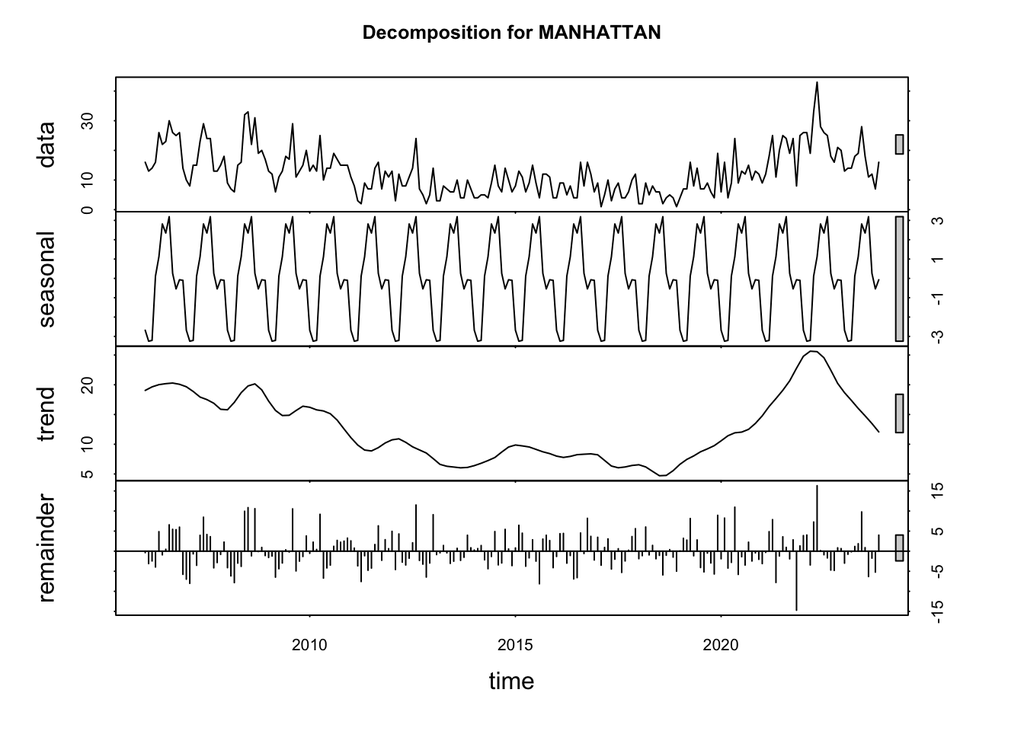

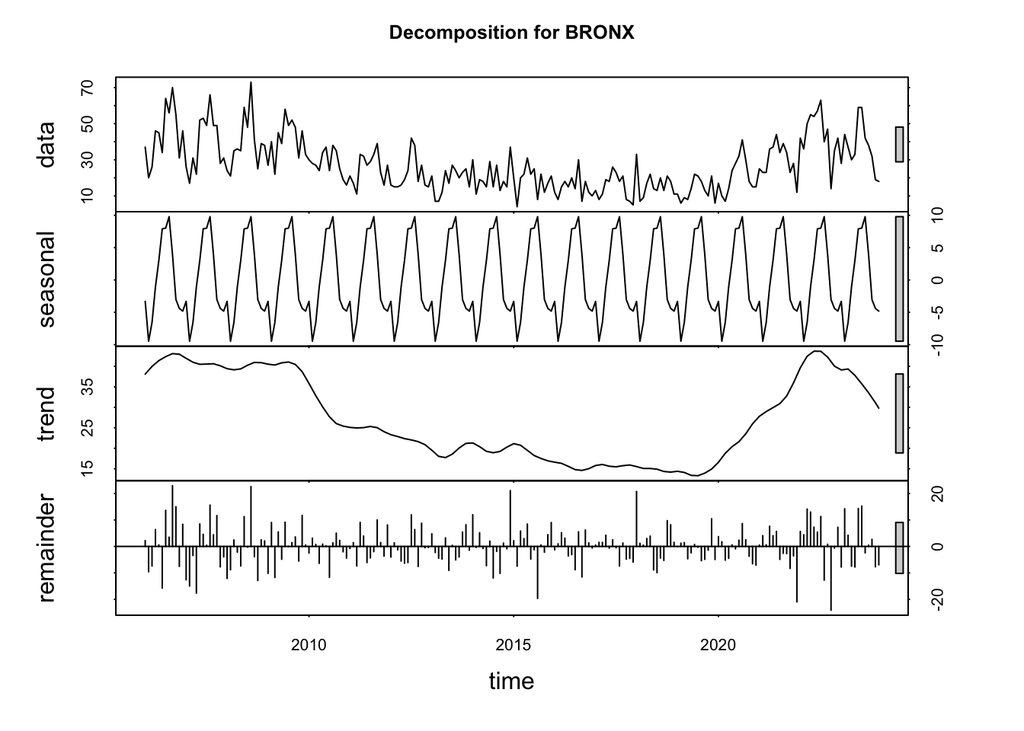

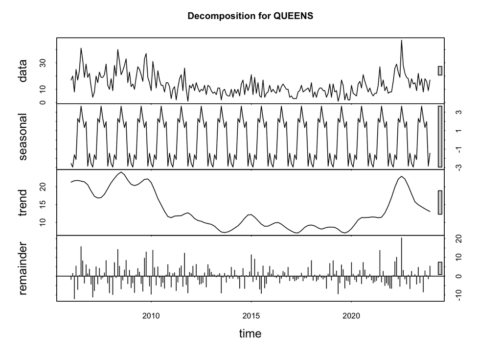

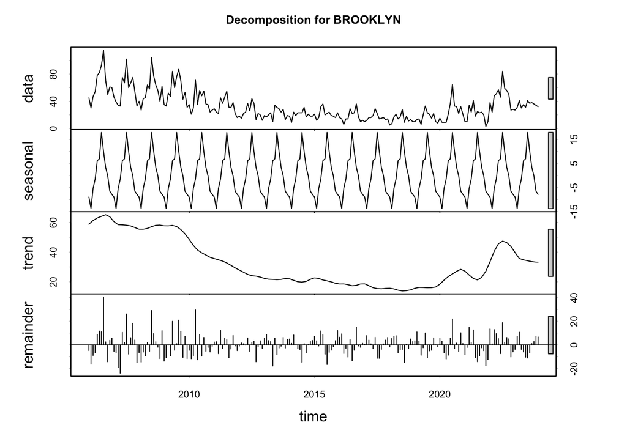

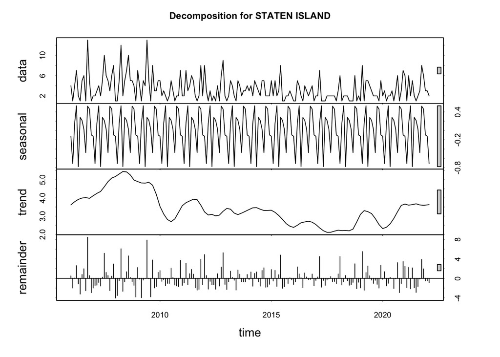

```r
#generate dataframe or borough names
boroughs <- unique(shooting_by_month$BORO)

#loop through each borough in the shooting_by_month dataframe and filter only the
#borough in this loop and arrange by year and month
for (boro in boroughs) {
  borough_data <- shooting_by_month %>%
    filter(BORO == boro) %>%
    arrange(year, month)

  #generate original time series without correction
  orig_ts <- ts(borough_data$count,
                start = c(min(borough_data$year), min(borough_data$month)),
                frequency = 12)

  #generate time series data corrected for seasonality
  decomposed_ts <- stl(orig_ts, s.window = "periodic")

  #make a plot for the current borough
  plot(decomposed_ts, main = paste("Decomposition for", boro))
}
```

## Additional Questions

Additional questions I have are about using some new techniques that I’ve learned about while researching time series analysis:

1. I’d like to conduct and understand forecast::auto.arima() analysis on the data and learn how to interpret these outputs.
2. I’d like to learn how to do forecasting on time series data to make predictions about what the future might hold.